# The tidycat package: expand broom::tidy() output for categorical parameter estimates

[figure not shown]

## Introduction

The `tidycat` package includes the `tidy_categorical()` function to expand `broom::tidy()` outputs for categorical parameter estimates.

## Installation

You can install the released version of tidycat from [CRAN](https://CRAN.R-project.org) with:

```r
install.packages("tidycat")
```

And the development version from [GitHub](https://github.com/) with:

```r
# install.packages("devtools")
devtools::install_github("guyabel/tidycat")
```

## Additional columns for categorical parameter estimates

The `tidy()` function in the broom package takes the messy output of built-in functions in R, such as `lm()`, and turns them into tidy data frames.

```r
library(dplyr)
library(broom)
m0 <- esoph %>%
   mutate_if(is.factor, ~factor(., ordered = FALSE)) %>%
   glm(cbind(ncases, ncontrols) ~ agegp + tobgp + alcgp, data = ., family = binomial())
# tidy
tidy(m0)
```

```
#> # A tibble: 12 x 5
#>    term        estimate std.error statistic  p.value
#>    <chr>          <dbl>     <dbl>     <dbl>    <dbl>
#>  1 (Intercept)   -6.90      1.09      -6.35 2.16e-10
#>  2 agegp35-44     1.98      1.10       1.79 7.28e- 2
#>  3 agegp45-54     3.78      1.07       3.54 4.07e- 4
#>  4 agegp55-64     4.34      1.07       4.07 4.69e- 5
#>  5 agegp65-74     4.90      1.08       4.55 5.39e- 6
#>  6 agegp75+       4.83      1.12       4.30 1.67e- 5
#>  7 tobgp10-19     0.438     0.228      1.92 5.50e- 2
#>  8 tobgp20-29     0.513     0.273      1.88 6.04e- 2
#>  9 tobgp30+       1.64      0.344      4.77 1.85e- 6
#> 10 alcgp40-79     1.43      0.250      5.74 9.63e- 9
#> 11 alcgp80-119    1.98      0.285      6.96 3.51e-12
#> 12 alcgp120+      3.60      0.385      9.36 8.19e-21
```

Note: Currently ordered factor not supported in `tidycat`, hence their removal in `mutate_if()` above

The `tidy_categorical()` function adds further columns (`variable`, `level` and `effect`) to the `broom::tidy()` output to help manage categorical variables

```r
library(tidycat)
m0 %>%
  tidy() %>%
  tidy_categorical(m = m0, include_reference =  FALSE)
```

```
#> # A tibble: 12 x 8
#>    term       estimate std.error statistic  p.value variable    level     effect
#>    <chr>         <dbl>     <dbl>     <dbl>    <dbl> <chr>       <fct>     <chr>
#>  1 (Intercep~   -6.90      1.09      -6.35 2.16e-10 (Intercept) (Interce~ main
#>  2 agegp35-44    1.98      1.10       1.79 7.28e- 2 agegp       35-44     main
#>  3 agegp45-54    3.78      1.07       3.54 4.07e- 4 agegp       45-54     main
#>  4 agegp55-64    4.34      1.07       4.07 4.69e- 5 agegp       55-64     main
#>  5 agegp65-74    4.90      1.08       4.55 5.39e- 6 agegp       65-74     main
#>  6 agegp75+      4.83      1.12       4.30 1.67e- 5 agegp       75+       main
#>  7 tobgp10-19    0.438     0.228      1.92 5.50e- 2 tobgp       10-19     main
#>  8 tobgp20-29    0.513     0.273      1.88 6.04e- 2 tobgp       20-29     main
#>  9 tobgp30+      1.64      0.344      4.77 1.85e- 6 tobgp       30+       main
#> 10 alcgp40-79    1.43      0.250      5.74 9.63e- 9 alcgp       40-79     main
#> 11 alcgp80-1~    1.98      0.285      6.96 3.51e-12 alcgp       80-119    main
#> 12 alcgp120+     3.60      0.385      9.36 8.19e-21 alcgp       120+      main
```

## Additional rows for reference categories

Include additional rows for reference category terms and a column to indicate their location by setting `include_reference = TRUE` (default). Setting `exponentiate = TRUE` ensures the parameter estimates in the reference group are set to one instead of zero (even odds in the logistic regression example below).

```r
m0 %>%
  tidy(exponentiate = TRUE) %>%
  tidy_categorical(m = m0, exponentiate = TRUE, reference_label = "Baseline") %>%
  select(-statistic, -p.value)
```

```
#> # A tibble: 15 x 7
#>    term         estimate std.error variable    level       effect reference
#>    <chr>           <dbl>     <dbl> <chr>       <fct>       <chr>  <chr>
#>  1 (Intercept)   0.00101     1.09  (Intercept) (Intercept) main   Non-Baseline
#>  2 <NA>          1           1     agegp       25-34       main   Baseline
#>  3 agegp35-44    7.25        1.10  agegp       35-44       main   Non-Baseline
#>  4 agegp45-54   43.7         1.07  agegp       45-54       main   Non-Baseline
#>  5 agegp55-64   76.3         1.07  agegp       55-64       main   Non-Baseline
#>  6 agegp65-74  134.          1.08  agegp       65-74       main   Non-Baseline
#>  7 agegp75+    125.          1.12  agegp       75+         main   Non-Baseline
#>  8 <NA>          1           1     tobgp       0-9g/day    main   Baseline
#>  9 tobgp10-19    1.55        0.228 tobgp       10-19       main   Non-Baseline
#> 10 tobgp20-29    1.67        0.273 tobgp       20-29       main   Non-Baseline
#> 11 tobgp30+      5.16        0.344 tobgp       30+         main   Non-Baseline
#> 12 <NA>          1           1     alcgp       0-39g/day   main   Baseline
#> 13 alcgp40-79    4.20        0.250 alcgp       40-79       main   Non-Baseline
#> 14 alcgp80-119   7.25        0.285 alcgp       80-119      main   Non-Baseline
#> 15 alcgp120+    36.7         0.385 alcgp       120+        main   Non-Baseline
```

## Standard coefficient plots

The results from `broom::tidy()` can be used to quickly plot estimated coefficients and their confidence intervals.

```r
# store parameter estimates and confidence intervals (except for the intercept)
d0 <- m0 %>%
  tidy(conf.int = TRUE) %>%
  slice(-1)
d0
```

```
#> # A tibble: 11 x 7
#>    term        estimate std.error statistic  p.value conf.low conf.high
#>    <chr>          <dbl>     <dbl>     <dbl>    <dbl>    <dbl>     <dbl>
#>  1 agegp35-44     1.98      1.10       1.79 7.28e- 2   0.184      4.95
#>  2 agegp45-54     3.78      1.07       3.54 4.07e- 4   2.10       6.71
#>  3 agegp55-64     4.34      1.07       4.07 4.69e- 5   2.67       7.27
#>  4 agegp65-74     4.90      1.08       4.55 5.39e- 6   3.21       7.84
#>  5 agegp75+       4.83      1.12       4.30 1.67e- 5   3.00       7.82
#>  6 tobgp10-19     0.438     0.228      1.92 5.50e- 2  -0.0116     0.885
#>  7 tobgp20-29     0.513     0.273      1.88 6.04e- 2  -0.0290     1.04
#>  8 tobgp30+       1.64      0.344      4.77 1.85e- 6   0.967      2.32
#>  9 alcgp40-79     1.43      0.250      5.74 9.63e- 9   0.955      1.94
#> 10 alcgp80-119    1.98      0.285      6.96 3.51e-12   1.43       2.55
#> 11 alcgp120+      3.60      0.385      9.36 8.19e-21   2.87       4.39
```

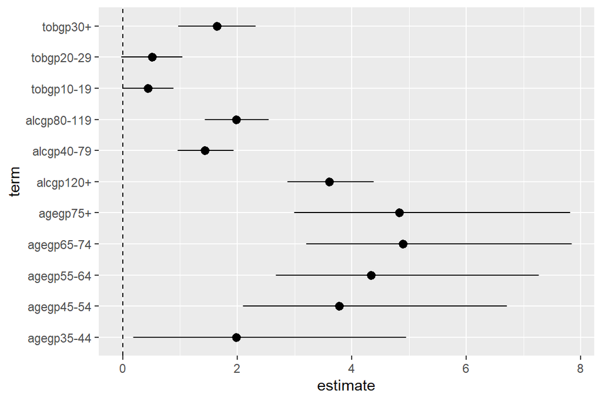

```r
library(ggplot2)
library(tidyr)
ggplot(data = d0,
        mapping = aes(x = term, y = estimate, ymin = conf.low, ymax = conf.high)) +
   coord_flip() +
   geom_hline(yintercept = 0, linetype = "dashed") +
   geom_pointrange()
```

## Enhanced coefficient plots

The additional columns from `tidy_categorical()` can be used to group together terms from the same categorical variable by setting `colour = variable`

```r
d0 <- m0 %>%
  tidy(conf.int = TRUE) %>%
  tidy_categorical(m = m0, include_reference = FALSE) %>%
  slice(-1)

d0 %>%
  select(-(3:5))
```

```
#> # A tibble: 11 x 7
#>    term        estimate conf.low conf.high variable level  effect
#>    <chr>          <dbl>    <dbl>     <dbl> <chr>    <fct>  <chr>
#>  1 agegp35-44     1.98    0.184      4.95  agegp    35-44  main
#>  2 agegp45-54     3.78    2.10       6.71  agegp    45-54  main
#>  3 agegp55-64     4.34    2.67       7.27  agegp    55-64  main
#>  4 agegp65-74     4.90    3.21       7.84  agegp    65-74  main
#>  5 agegp75+       4.83    3.00       7.82  agegp    75+    main
#>  6 tobgp10-19     0.438  -0.0116     0.885 tobgp    10-19  main
#>  7 tobgp20-29     0.513  -0.0290     1.04  tobgp    20-29  main
#>  8 tobgp30+       1.64    0.967      2.32  tobgp    30+    main
#>  9 alcgp40-79     1.43    0.955      1.94  alcgp    40-79  main
#> 10 alcgp80-119    1.98    1.43       2.55  alcgp    80-119 main
#> 11 alcgp120+      3.60    2.87       4.39  alcgp    120+   main
```

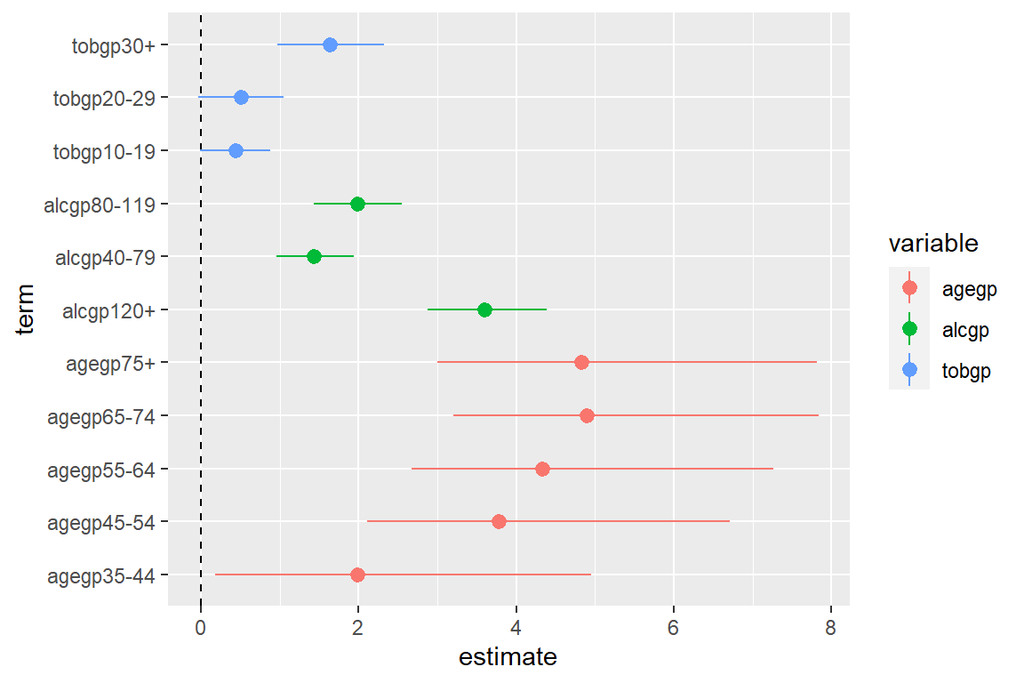

```r
ggplot(data = d0,
        mapping = aes(x = term, y = estimate, ymin = conf.low, ymax = conf.high,
                      colour = variable)) +
   coord_flip() +
   geom_hline(yintercept = 0, linetype = "dashed") +
   geom_pointrange()
```

The additional rows from `tidy_categorical()` can be used to include the reference categories in a coefficient plot, allowing the reader to better grasp the meaning of the parameter estimates in each categorical variable. Using `ggforce::facet_col()` the terms of each variable can be separated to further improve the presentation of the coefficient plot.

```r
d0 <- m0 %>%
  tidy(conf.int = TRUE) %>%
  tidy_categorical(m = m0) %>%
  slice(-1)

d0 %>%
  select(-(3:5))
```

```
#> # A tibble: 14 x 8
#>    term      estimate conf.low conf.high variable level   effect reference
#>    <chr>        <dbl>    <dbl>     <dbl> <chr>    <fct>   <chr>  <chr>
#>  1 <NA>         0       0          0     agegp    25-34   main   Baseline Categ~
#>  2 agegp35-~    1.98    0.184      4.95  agegp    35-44   main   Non-Baseline C~
#>  3 agegp45-~    3.78    2.10       6.71  agegp    45-54   main   Non-Baseline C~
#>  4 agegp55-~    4.34    2.67       7.27  agegp    55-64   main   Non-Baseline C~
#>  5 agegp65-~    4.90    3.21       7.84  agegp    65-74   main   Non-Baseline C~
#>  6 agegp75+     4.83    3.00       7.82  agegp    75+     main   Non-Baseline C~
#>  7 <NA>         0       0          0     tobgp    0-9g/d~ main   Baseline Categ~
#>  8 tobgp10-~    0.438  -0.0116     0.885 tobgp    10-19   main   Non-Baseline C~
#>  9 tobgp20-~    0.513  -0.0290     1.04  tobgp    20-29   main   Non-Baseline C~
#> 10 tobgp30+     1.64    0.967      2.32  tobgp    30+     main   Non-Baseline C~
#> 11 <NA>         0       0          0     alcgp    0-39g/~ main   Baseline Categ~
#> 12 alcgp40-~    1.43    0.955      1.94  alcgp    40-79   main   Non-Baseline C~
#> 13 alcgp80-~    1.98    1.43       2.55  alcgp    80-119  main   Non-Baseline C~
#> 14 alcgp120+    3.60    2.87       4.39  alcgp    120+    main   Non-Baseline C~
```

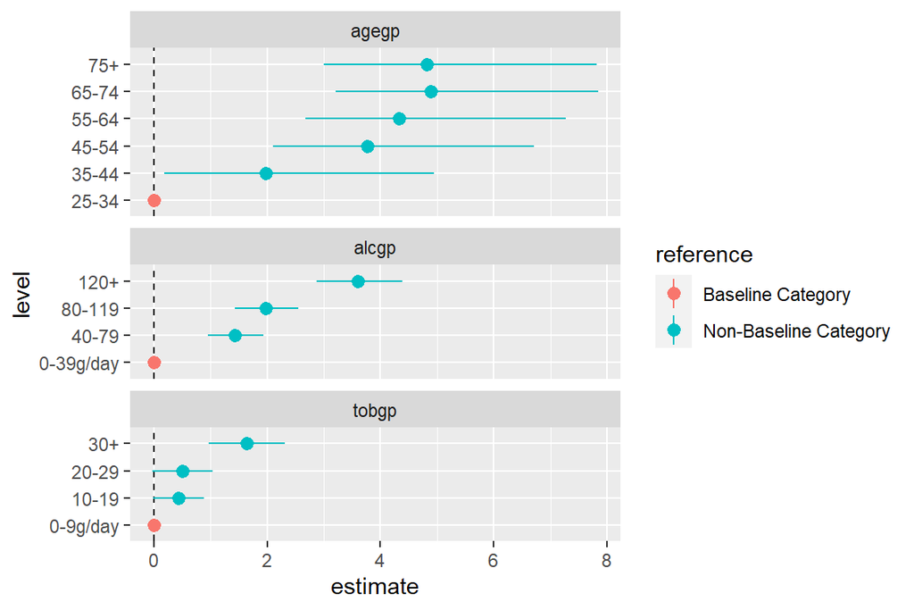

```r
library(ggforce)
ggplot(data = d0,
        mapping = aes(x = level, y = estimate, colour = reference,
                      ymin = conf.low, ymax = conf.high)) +
   facet_col(facets = vars(variable), scales = "free_y", space = "free") +
   coord_flip() +
   geom_hline(yintercept = 0, linetype = "dashed") +
   geom_pointrange()
```

Note the switch of the `x` aesthetic to the `level` column rather than `term`.

Alternatively, horizontal plots can be obtained using `ggforce::facet_row()` and loosing `coord_flip()`;

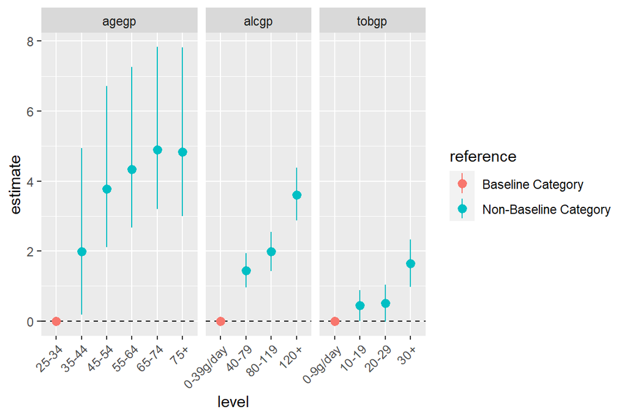

```r
ggplot(data = d0,
      mapping = aes(x = level, y = estimate,
                    ymin = conf.low, ymax = conf.high,
                    colour = reference)) +
 facet_row(facets = vars(variable), scales = "free_x", space = "free") +
 geom_hline(yintercept = 0, linetype = "dashed") +
 geom_pointrange() +
 theme(axis.text.x = element_text(angle = 45, hjust = 1))
```

## Interactions

Models with interactions can also be handled in `tidy_categorical()`. Using the `mtcars` data we can create three types of interactions (between two numeric variables, between a numeric variable and categorical variable and between two categorical variables)

```r
m1 <- mtcars %>%
  mutate(engine = recode_factor(vs, `0` = "straight", `1` = "V-shaped"),
         transmission = recode_factor(am, `0` = "automatic", `1` = "manual")) %>%
  lm(mpg ~ as.factor(cyl) + wt * hp + wt * transmission + engine * transmission , data = .)

tidy(m1)
```

```
#> # A tibble: 10 x 5
#>    term                              estimate std.error statistic p.value
#>    <chr>                                <dbl>     <dbl>     <dbl>   <dbl>
#>  1 (Intercept)                        35.5      12.3        2.89  0.00843
#>  2 as.factor(cyl)6                    -1.03      1.76      -0.585 0.565
#>  3 as.factor(cyl)8                     2.01      4.09       0.492 0.628
#>  4 wt                                 -4.65      3.55      -1.31  0.203
#>  5 hp                                 -0.0731    0.0577    -1.27  0.218
#>  6 transmissionmanual                 10.7      10.0        1.07  0.296
#>  7 engineV-shaped                      3.74      3.21       1.16  0.257
#>  8 wt:hp                               0.0134    0.0162     0.828 0.416
#>  9 wt:transmissionmanual              -2.63      2.83      -0.930 0.362
#> 10 transmissionmanual:engineV-shaped  -3.16      3.76      -0.842 0.409
```

Setting `n_level = TRUE` creates an additional column to monitor the number of observations in each of level of the categorical variables, including interaction terms in the model:

```r
d1 <- m1 %>%
  tidy(conf.int = TRUE) %>%
  tidy_categorical(m = m1, n_level = TRUE) %>%
  slice(-1)

d1 %>%
  select(-(2:7))
```

```
#> # A tibble: 16 x 6
#>    term               variable       level       effect   reference      n_level
#>    <chr>              <chr>          <fct>       <chr>    <chr>            <dbl>
#>  1 <NA>               as.factor(cyl) 4           main     Baseline Cate~      11
#>  2 as.factor(cyl)6    as.factor(cyl) 6           main     Non-Baseline ~       7
#>  3 as.factor(cyl)8    as.factor(cyl) 8           main     Non-Baseline ~      14
#>  4 wt                 wt             wt          main     Non-Baseline ~      NA
#>  5 hp                 hp             hp          main     Non-Baseline ~      NA
#>  6 <NA>               transmission   automatic   main     Baseline Cate~      19
#>  7 transmissionmanual transmission   manual      main     Non-Baseline ~      13
#>  8 <NA>               engine         straight    main     Baseline Cate~      18
#>  9 engineV-shaped     engine         V-shaped    main     Non-Baseline ~      14
#> 10 wt:hp              wt:hp          wt:hp       interac~ Non-Baseline ~      NA
#> 11 <NA>               wt:transmissi~ automatic   interac~ Baseline Cate~      19
#> 12 wt:transmissionma~ wt:transmissi~ manual      interac~ Non-Baseline ~      13
#> 13 <NA>               transmission:~ automatic:~ interac~ Baseline Cate~      25
#> 14 <NA>               transmission:~ manual:str~ interac~ Non-Baseline ~       0
#> 15 <NA>               transmission:~ automatic:~ interac~ Non-Baseline ~       0
#> 16 transmissionmanua~ transmission:~ manual:V-s~ interac~ Non-Baseline ~       7
```

We can use similar plotting code as above to plot the interactions:

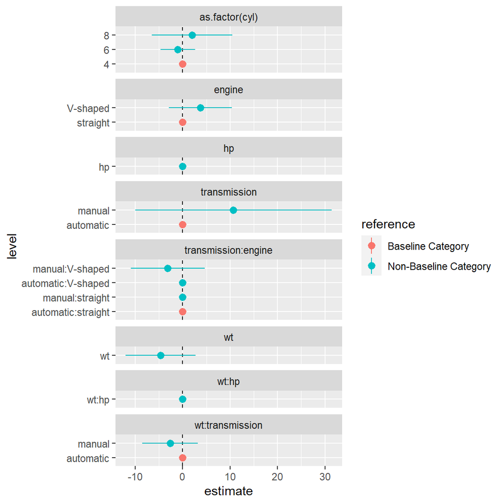

```r
ggplot(data = d1,
        mapping = aes(x = level, y = estimate, colour = reference,
                      ymin = conf.low, ymax = conf.high)) +
   facet_col(facets = "variable", scales = "free_y", space = "free") +
   coord_flip() +
   geom_hline(yintercept = 0, linetype = "dashed") +
   geom_pointrange()
```

The empty levels can be dropped by filtering on the `n_level` column for categories with more than zero observations and not `NA` in term column.

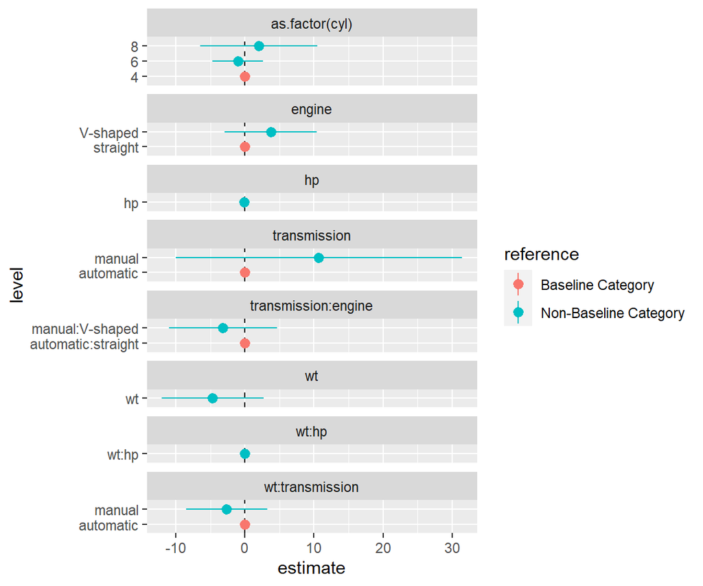

```r
d1 %>%
  dplyr::filter(n_level > 0 | !is.na(term)) %>%
  ggplot(mapping = aes(x = level, y = estimate, colour = reference,
                       ymin = conf.low, ymax = conf.high)) +
  facet_col(facets = "variable", scales = "free_y", space = "free") +
  coord_flip() +
  geom_hline(yintercept = 0, linetype = "dashed") +
  geom_pointrange()
```

## Issues

If you have any trouble or suggestions please let me know by creating an issue on the [tidycat Github](https://github.com/guyabel/tidycat/issues)